# Grouping of Spain provinces based on socio-economic data

Grouping of Spain provinces based on population, density, natality, mortality, GDP to identify potential marketing campaings

Mauricio Corrales  
2023-11-11

```r
# Import of libraries
rm(list = ls())
library(tidyverse)
library(tidymodels)
library(corrplot)
library(readxl)
library(skimr)
library(factoextra)
library(FactoMineR)
library(cluster)
library(kableExtra)
```

# Loading of the data

```r
provincias <- read_xlsx(path = "./data/provincias.xlsx")
glimpse(provincias)
```

```
Rows: 52
Columns: 19
$ Prov          <chr> "Albacete", "Alicante", "Almería", "Álava", "A…
$ Poblacion     <dbl> 396987, 1868438, 701688, 321932, 1061756, 6909…
$ Mortalidad    <dbl> 9.41, 8.00, 6.91, 7.72, 12.16, 9.54, 7.08, 8.1…
$ Natalidad     <dbl> 9.02, 8.52, 11.41, 10.26, 6.26, 8.96, 9.51, 9.…
$ IPC           <dbl> 101.819, 102.309, 101.454, 102.743, 102.070, 1…
$ NumEmpresas   <dbl> 26701, 130438, 40327, 19548, 67451, 39640, 871…
$ Industria     <dbl> 3332, 9992, 2191, 2048, 3496, 3059, 4413, 2741…
$ Construccion  <dbl> 3428, 17418, 5388, 2669, 8435, 4599, 14485, 50…
$ CTH           <dbl> 11111, 52720, 18184, 7557, 28045, 18420, 30644…
$ Infor         <dbl> 189, 1851, 366, 323, 787, 332, 1403, 11134, 15…
$ AFS           <dbl> 624, 2745, 944, 354, 1445, 948, 1627, 8829, 16…
$ APT           <dbl> 3278, 19865, 5840, 3341, 10598, 5235, 16444, 8…
$ TasaActividad <dbl> 57.72, 58.21, 60.63, 57.86, 51.42, 56.00, 68.6…
$ TasaParo      <dbl> 23.28, 23.39, 31.08, 13.33, 16.97, 29.63, 13.8…
$ Ocupados      <dbl> 144.8, 687.1, 234.4, 133.0, 389.0, 224.6, 555.…
$ PIB           <dbl> 7235991, 32139347, 11909684, 10716021, 2177043…
$ CANE          <dbl> 20888, 25968, 22945, 3691, 23910, 37438, 10748…
$ TVF           <dbl> 215948, 1274096, 395086, 155767, 613905, 37249…
$ VS            <dbl> 30244, 326705, 72486, 9791, 73250, 49441, 8571…
```

Some of the variables include:

- `Prov`: province name
- `Poblacion`: population
- `Mortalidad`, `Natalidad`: mortality/natality rate (per thousand)
- `IPC`: consumer price index (based on a base value of 100).
- `NumEmpresas`: number of companies.
- `PIB`: gross domestic product
- `CTH`: hotel tourism situation (overnight stays in hotel establishments)

# Correlation and Covariance Matrices, Eigenvalues, and Eigenvectors.

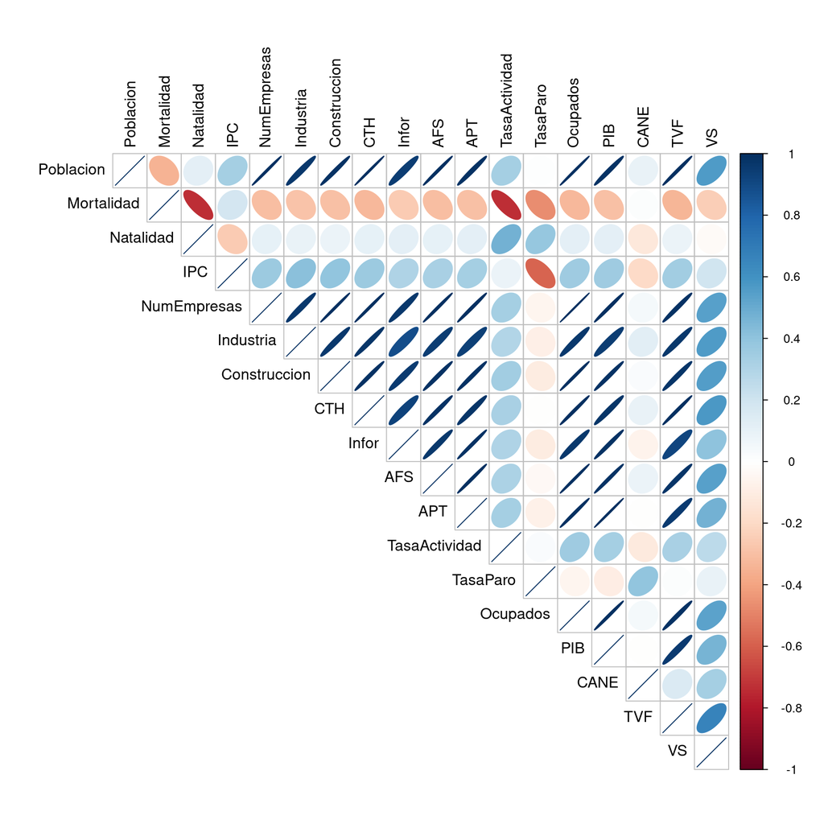

```r
# We calculate the covariance and correlation matrices and represent them graphically.
cov_mat <-
  provincias %>% select (-Prov) %>% cov()

cor_mat <-
  provincias %>% select (-Prov) %>% cor()

corrplot(cor_mat, type = "upper",
         tl.col = "black",  method = "ellipse")
```

We observe several variables with high correlations among them. For instance, the variables Poblacion (Population), NumEmpresas (Number of Companies), Industrias (Industries), Construccion (Construction), CTH (Hotel Tourism Situation), AFS, APT, Ocupados (Occupied), PIB (Gross Domestic Product), and TVF show a high linear correlation in an upward direction.

```r
# We calculate the eigenvalues and eigenvectors.
autoval <-
  eigen(cor_mat)
autoval$values
```

```
 [1] 1.146640e+01 2.560508e+00 1.634097e+00 9.340488e-01 4.565320e-01
 [6] 4.143630e-01 3.071743e-01 1.166154e-01 7.309913e-02 2.034496e-02
[11] 9.027568e-03 3.566115e-03 2.372720e-03 8.013952e-04 5.472749e-04
[16] 3.512710e-04 1.028975e-04 4.950858e-05
```

```r
autoval$vectors
```

```
             [,1]         [,2]         [,3]        [,4]         [,5]
 [1,]  0.29352698  0.002493342  0.049947340 -0.05339540 -0.015898841
 [2,] -0.10629199 -0.527120141  0.188867032 -0.16131678  0.024146585
 [3,]  0.04062702  0.495419403 -0.270681171 -0.10967036 -0.382061614
 [4,]  0.10991169 -0.365322291 -0.262317619  0.43504738 -0.556757431
 [5,]  0.29418239 -0.026147510  0.007952241 -0.06913798 -0.006367061
 [6,]  0.28562283 -0.044737470  0.046369149  0.02345108 -0.150042973
 [7,]  0.29326489 -0.045381770 -0.012082096 -0.02639413  0.008113738
 [8,]  0.29286608 -0.010617503  0.048841149 -0.02758090 -0.028366126
 [9,]  0.28150192 -0.042018125 -0.064640257 -0.22152688  0.070433510
[10,]  0.29246592 -0.016454205  0.039554303 -0.09168100  0.003041574
[11,]  0.29072490 -0.029433207 -0.028068230 -0.14186101  0.031732816
[12,]  0.11433729  0.330614591 -0.362734482  0.46305159  0.133043722
[13,] -0.01399634  0.461562171  0.387356995 -0.22020186 -0.055362718
[14,]  0.29442838 -0.016838806  0.002429338 -0.06005252 -0.001232463
```

[output cut: 80 more lines]

# PCA Analysis

```r
# We calculate all the principal components.
pca_fit <- PCA(provincias, scale.unit = TRUE, ncp = ncol(provincias), quali.sup = 1, graph = FALSE)
pca_fit$eig
```

```
          eigenvalue percentage of variance
comp 1  1.146640e+01           6.370222e+01
comp 2  2.560508e+00           1.422504e+01
comp 3  1.634097e+00           9.078315e+00
comp 4  9.340488e-01           5.189160e+00
comp 5  4.565320e-01           2.536289e+00
comp 6  4.143630e-01           2.302017e+00
comp 7  3.071743e-01           1.706524e+00
comp 8  1.166154e-01           6.478631e-01
comp 9  7.309913e-02           4.061063e-01
comp 10 2.034496e-02           1.130275e-01
comp 11 9.027568e-03           5.015315e-02
comp 12 3.566115e-03           1.981175e-02
comp 13 2.372720e-03           1.318178e-02
comp 14 8.013952e-04           4.452195e-03
comp 15 5.472749e-04           3.040416e-03
comp 16 3.512710e-04           1.951506e-03
comp 17 1.028975e-04           5.716530e-04
comp 18 4.950858e-05           2.750477e-04
        cumulative percentage of variance
comp 1                           63.70222
comp 2                           77.92726
comp 3                           87.00558
comp 4                           92.19474
comp 5                           94.73102
comp 6                           97.03304
comp 7                           98.73957
comp 8                           99.38743
comp 9                           99.79353
comp 10                          99.90656
comp 11                          99.95672
comp 12                          99.97653
comp 13                          99.98971
comp 14                          99.99416
comp 15                          99.99720
comp 16                          99.99915
comp 17                          99.99972
comp 18                         100.00000
```

```r
# We observe that with 6 components, we represent 95% of the information.
pca_fit <- PCA(provincias, scale.unit = TRUE, ncp = 6, quali.sup = 1, graph = FALSE)
```

## Graphic representation of explained variance

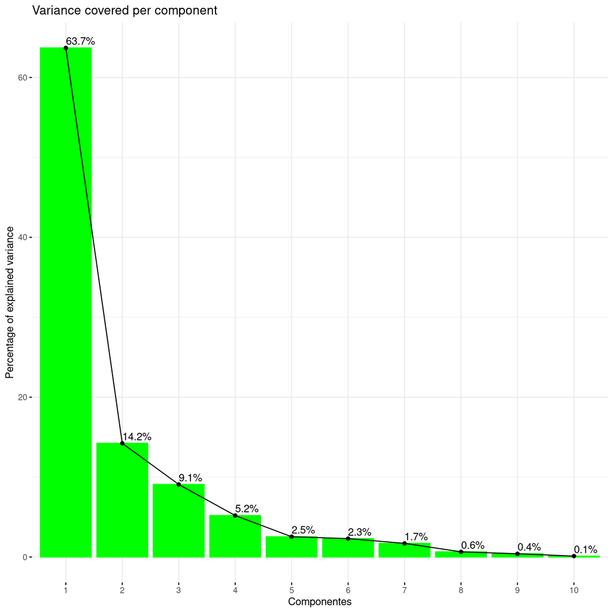

```r
# Amount of variance covered per component
fviz_eig(pca_fit, addlabels = TRUE, barfill = "green",
         barcolor = "green", xlab = "Componentes",
         ylab = "Percentage of explained variance",
         main = "Variance covered per component")
```

## New coordinates of the data

```r
pca_fit$ind$coord
```

```
         Dim.1         Dim.2       Dim.3       Dim.4       Dim.5
1  -1.41017686  0.4734423651  0.09617150 -0.45796713  0.13095494
2   3.38367603  0.5397505581  1.91865320  2.42036146 -1.93760003
3  -0.61651226  2.6139666809  0.20772292 -0.14164444 -0.04194355
4  -1.44429594 -0.0008444871 -2.03183179 -0.11310052  0.46785078
5  -0.20350137 -1.9525986131  1.29786007 -0.71388934 -0.36860431
6  -1.04846596  1.1677693270  1.79554023 -0.85440440  0.07544289
7   1.52621574  0.2601071540 -2.51922849  2.36354690  0.48085217
8  13.68268794 -1.6121155618 -0.86679541 -0.27855369  1.03981506
9   0.57644373 -1.5081871153 -1.17979880 -0.38255980  0.79824422
10 -1.20182455 -1.5496195139 -0.89154966  0.98854013  0.60182044
11 -0.84908539 -1.1259429948 -0.59433092  0.40115869 -0.13074923
12 -0.68987702  0.8209167732  0.51814851  0.38168516 -0.54791911
13 -2.12522644  3.3258586141 -1.81108385 -1.16466618  0.29805470
14 -1.39218950  0.8151885534  1.81886692 -0.77389817  0.21646631
```

[output cut: 91 more lines]

## Contribution of the original variables in each selected principal component.

```r
pca_fit$var$contrib
```

```
                   Dim.1        Dim.2        Dim.3       Dim.4
Poblacion     8.61580869 6.216756e-04 2.494737e-01  0.28510690
Mortalidad    1.12979868 2.778556e+01 3.567076e+00  2.60231048
Natalidad     0.16505544 2.454404e+01 7.326830e+00  1.20275871
IPC           1.20805785 1.334604e+01 6.881053e+00 18.92662230
NumEmpresas   8.65432772 6.836923e-02 6.323813e-03  0.47800598
Industria     8.15804006 2.001441e-01 2.150098e-01  0.05499531
Construccion  8.60042932 2.059505e-01 1.459770e-02  0.06966501
CTH           8.57705398 1.127314e-02 2.385458e-01  0.07607058
Infor         7.92433313 1.765523e-01 4.178363e-01  4.90741583
AFS           8.55363151 2.707409e-02 1.564543e-01  0.84054061
APT           8.45209684 8.663137e-02 7.878255e-02  2.01245468
TasaActividad 1.30730170 1.093060e+01 1.315763e+01 21.44167757
TasaParo      0.01958975 2.130396e+01 1.500454e+01  4.84888573
Ocupados      8.66880711 2.835454e-02 5.901685e-04  0.36063054
PIB           8.46269279 1.307379e-01 1.405631e-01  1.78508842
CANE          0.03164342 9.251454e-01 4.313115e+01  7.75029908
TVF           8.50111166 2.558733e-04 9.952426e-01  0.19487506
VS            2.97022035 2.286851e-01 8.418293e+00 32.16259720
                     Dim.5        Dim.6
Poblacion     2.527731e-02  0.008577510
Mortalidad    5.830576e-02  0.113808680
Natalidad     1.459711e+01  9.825724095
IPC           3.099788e+01 12.301662219
NumEmpresas   4.053946e-03  0.004628499
Industria     2.251289e+00  0.379668213
Construccion  6.583274e-03  0.003921397
CTH           8.046371e-02  0.223154480
Infor         4.960879e-01  1.577980441
AFS           9.251174e-04  0.299366263
APT           1.006972e-01  0.640893842
TasaActividad 1.770063e+00 27.932330747
TasaParo      3.065031e-01  9.253743706
Ocupados      1.518964e-04  0.159122519
PIB           7.434893e-03  0.593372087
CANE          2.381808e+01 17.575176869
TVF           2.178721e-01  0.543501985
VS            2.526122e+01 18.563366447
```

## Least explained variable

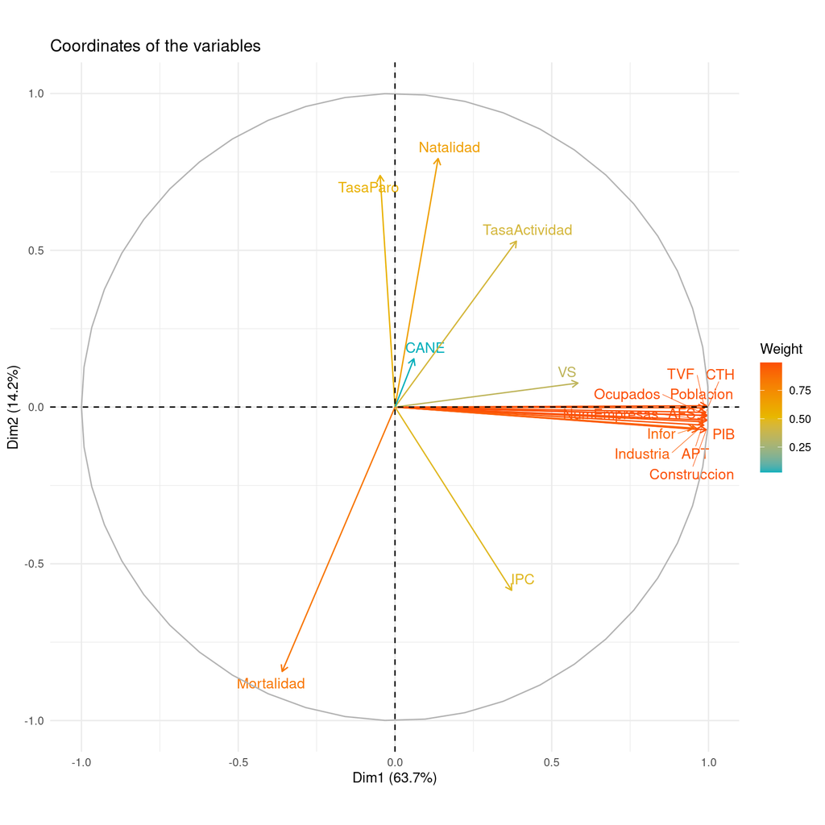

```r
col <- c("#00AFBB", "#E7B800", "#FC4E07")
fviz_pca_var(pca_fit, col.var = "cos2",
             gradient.cols = col,
             repel = TRUE) +
  theme_minimal() +
  labs(title = "Coordinates of the variables",
       color = "Weight")
```

The variable that is least explained in terms of the first two principal components is the variable CANE, as observed in the previous graph.

## Socioeconomic indexes for some provinces of interest

```r
# Lineal combination to obtain the socioeconomic index
provincias %>% select(Prov) %>% bind_cols(pca_fit$ind$coord) %>% kable (caption = "Equivalent Principal Components.")
```

Table 1: Equivalent Principal Components.

| Prov | Dim.1 | Dim.2 | Dim.3 | Dim.4 | Dim.5 | Dim.6 |
| --- | --- | --- | --- | --- | --- | --- |
| Albacete | -1.4101769 | 0.4734424 | 0.0961715 | -0.4579671 | 0.1309549 | -0.3789232 |
| Alicante | 3.3836760 | 0.5397506 | 1.9186532 | 2.4203615 | -1.9376000 | 1.7986029 |
| Almería | -0.6165123 | 2.6139667 | 0.2077229 | -0.1416444 | -0.0419435 | 0.0503753 |
| Álava | -1.4442959 | -0.0008445 | -2.0318318 | -0.1131005 | 0.4678508 | 0.0943750 |
| Asturias | -0.2035014 | -1.9525986 | 1.2978601 | -0.7138893 | -0.3686043 | 0.0167118 |
| Badajoz | -1.0484660 | 1.1677693 | 1.7955402 | -0.8544044 | 0.0754429 | -0.5746590 |
| Balears | 1.5262157 | 0.2601072 | -2.5192285 | 2.3635469 | 0.4808522 | -0.5672273 |
| Barcelona | 13.6826879 | -1.6121156 | -0.8667954 | -0.2785537 | 1.0398151 | 0.7654343 |
| Bizkaia | 0.5764437 | -1.5081871 | -1.1797988 | -0.3825598 | 0.7982442 | 0.4655748 |
| Burgos | -1.2018245 | -1.5496195 | -0.8915497 | 0.9885401 | 0.6018204 | 0.5321101 |
| Cantabria | -0.8490854 | -1.1259430 | -0.5943309 | 0.4011587 | -0.1307492 | 0.3910605 |
| Castellón | -0.6898770 | 0.8209168 | 0.5181485 | 0.3816852 | -0.5479191 | -0.2938680 |
| Ceuta | -2.1252264 | 3.3258586 | -1.8110838 | -1.1646662 | 0.2980547 | 0.6477562 |
| Ciudad Real | -1.3921895 | 0.8151886 | 1.8188669 | -0.7738982 | 0.2164663 | -0.5646216 |
| Coruña | 0.6352132 | -1.4418587 | 0.7586761 | 0.2438824 | 0.2578823 | -0.0461913 |
| Cuenca | -2.1322838 | -0.5693294 | 1.0482914 | -0.9316701 | -0.4775266 | -0.0804710 |
| Cáceres | -1.5027322 | -0.1797543 | 1.2692401 | -0.2232679 | -0.0411563 | 0.0741675 |
| Cádiz | 0.1280841 | 1.7712186 | 0.3686942 | -0.2485627 | -0.2594834 | 1.2731590 |
| Córdoba | -0.5935744 | 0.8106413 | 1.2915151 | -0.1689279 | 1.0843089 | -0.0136568 |
| Gipuzkoa | -0.2811018 | -1.4851526 | -1.8791558 | 0.2663338 | 1.1844991 | 0.4837904 |
| Girona | 0.3875085 | 0.5444285 | -1.3874126 | 1.6378286 | -0.6291078 | 0.5080088 |
| Granada | -0.0724031 | 1.1235421 | 1.5110376 | 0.5003168 | 0.7230122 | -0.0898434 |
| Guadalajara | -1.4075889 | 1.5419225 | -1.8494093 | 0.9056523 | -0.7876993 | -1.0167768 |
| Huelva | -1.2647424 | 1.1675386 | 0.0128759 | -0.3274352 | 0.0725088 | 0.9299898 |
| Huesca | -1.7755584 | -0.9839010 | -0.5873868 | 0.3039312 | -0.2903695 | -0.7929934 |
| Jaén | -1.2212786 | 1.4243452 | 3.4073238 | -0.4789805 | 1.4277004 | -1.0001005 |
| León | -1.4635639 | -2.0160746 | 0.8772927 | -0.8085839 | -0.2395261 | 0.6651650 |
| Lleida | -0.8352709 | -0.1355633 | -1.4718501 | 1.1850736 | 0.7405166 | -0.9235691 |
| Lugo | -1.8259535 | -2.7845330 | 0.8712655 | -0.3527810 | 0.3240498 | -0.1613080 |
| Madrid | 16.7782985 | -0.3659311 | -0.8491474 | -2.3648273 | -0.8804923 | -0.9742296 |
| Melilla | -2.2179459 | 4.7821957 | -1.9051614 | -2.2308254 | 0.7138309 | 1.4096604 |
| Murcia | 1.5221916 | 1.4419889 | 0.5801659 | 0.9007723 | 0.4365045 | 0.4062946 |
| Málaga | 2.0057801 | 1.3246290 | 0.8690342 | 1.1039610 | -0.3566375 | 0.7378239 |
| Navarra | -0.6533032 | 0.0783396 | -1.0956670 | -0.0811241 | 0.2290525 | -0.7037481 |
| Ourense | -1.9653231 | -2.8583466 | 1.0983556 | -1.2042155 | -0.3253275 | 0.8883842 |
| Palencia | -2.1224576 | -1.9505762 | -0.6951299 | -0.1422359 | 0.0497897 | 0.0414039 |
| Palmas | 0.0918428 | 1.8568628 | -0.3302519 | -0.8236478 | -1.3749483 | -0.5498620 |
| Pontevedra | 0.0360551 | -0.6068177 | 0.0520484 | -0.3277141 | -0.0160865 | 0.4194326 |
| Rioja | -1.3831751 | -0.4839450 | -1.3540117 | 0.2882904 | 0.2007773 | -0.2430245 |
| Salamanca | -1.6119953 | -1.4247516 | -0.1210697 | -0.0856866 | -0.5771136 | -0.2433986 |
| Santa Cruz | -0.0291917 | 1.5729750 | -0.1264997 | -0.4320673 | -1.5596542 | -0.7467011 |
| Segovia | -1.9311033 | -1.0149597 | -1.1096147 | 0.2628292 | -0.2662499 | -0.3991623 |
| Sevilla | 1.9482932 | 1.7745712 | 0.7119698 | -0.5455312 | 0.5486680 | -0.2050950 |
| Soria | -2.3990589 | -1.8572256 | -0.7779422 | -0.5034547 | -0.6563272 | -0.4198250 |
| Tarragona | 0.1754117 | 1.0403568 | -0.1019549 | 1.5120780 | -0.5370031 | -0.2250878 |
| Teruel | -2.1854169 | -1.0816087 | -0.3512177 | -0.4127919 | -0.5159140 | -0.4035443 |
| Toledo | -0.4614867 | 1.4488772 | 0.8116446 | 0.4632303 | 0.0474399 | -0.7640965 |
| Valencia | 4.7698318 | 0.3601408 | 2.9607302 | 2.3494484 | 0.9193606 | -0.2843651 |
| Valladolid | -1.0071037 | -0.7041391 | -1.0522419 | 0.1955946 | 0.2901468 | 0.0822965 |
| Zamora | -2.2866624 | -3.1694811 | 0.5777595 | -0.6218429 | 0.1672359 | 0.6351545 |
| Zaragoza | 0.1154084 | -0.2367336 | -0.1561435 | 0.0677439 | 0.1417260 | -0.8216290 |
| Ávila | -2.1515116 | -0.9815827 | 0.3650030 | -0.5454019 | -0.8510724 | 0.1712466 |

The index to assess the economic development of a province collectively, in this case, would be the first principal component. From the previous graph, we can see that most variables indicating economic development are represented in the first component, which also accounts for 63.7% of the variance. For Madrid, this index would be 16.77, and for Melilla -2.21, which makes sense as Madrid is one of the largest provinces with better indicators of economic development.

# Pre-clustering analysis

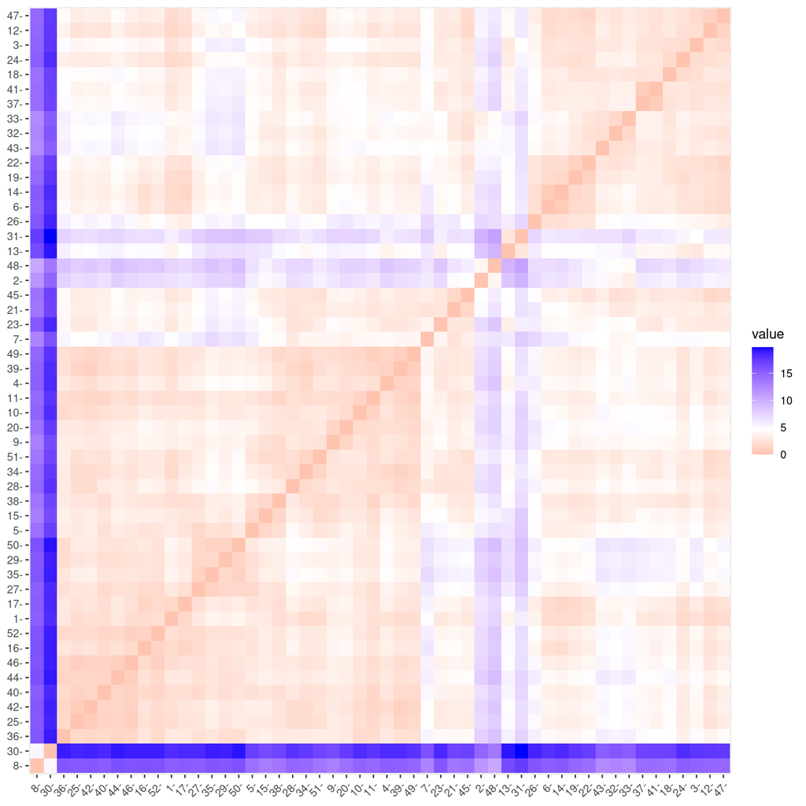

```r
# We calculate the distance matrix of the data and represent it with a heatmap.
d <- dist(provincias %>%
            select(-Prov) %>%
            mutate(across(where(is.numeric), ~scale(.))),
          method = "euclidean")

fviz_dist(d, show_labels = TRUE)
```

Indeed, with the heatmap presented earlier, groups of provinces are identified. A small square is observed in the lower-left corner, and a large group with a not very defined boundary is also noticeable, followed by two small groups, and finally, another large group. In general, approximately 5 potential groups of provinces are identified.

# Simple-linkage Clustering

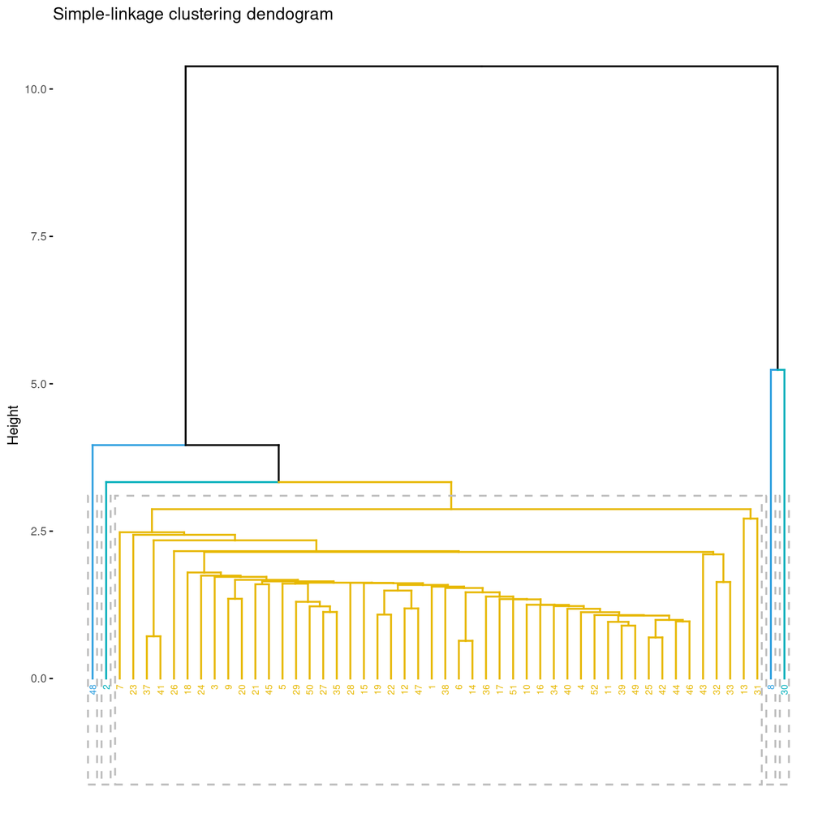

```r
single_clust <-
  hclust(d, method = "single")

fviz_dend(single_clust, k = 5,
          cex = 0.5,
          k_colors =
            c("#2E9FDF", "#00AFBB", "#E7B800"),
          color_labels_by_k = TRUE,
          rect = TRUE) +
  labs(title = "Simple-linkage clustering dendogram")
```

The first hierarchical cluster is performed with the simple-linkage method and with 5 clusters, as analyzed in the previous sections. We can observe that the clusters are not well-defined or evenly distributed.

## Complete-linkage clustering

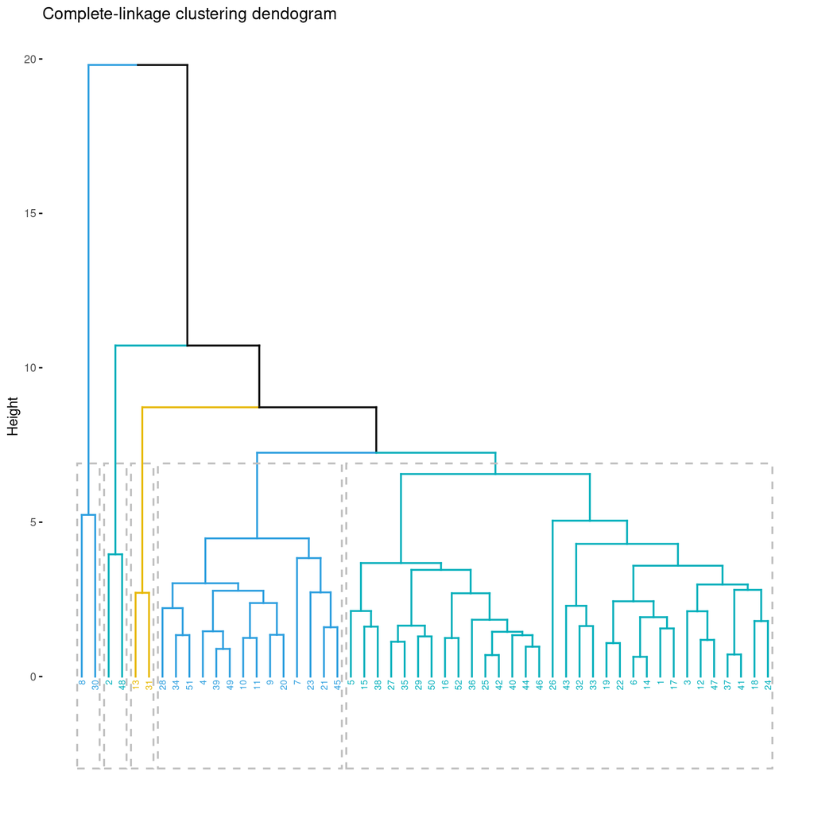

```r
complete_clust <-
  hclust(d, method = "complete")

fviz_dend(complete_clust, k = 5,
          cex = 0.5,
          k_colors =
            c("#2E9FDF", "#00AFBB", "#E7B800"),
          color_labels_by_k = TRUE,
          rect = TRUE) +
  labs(title = "Complete-linkage clustering dendogram")
```

The second hierarchical cluster is performed with the complete-linkage method and with 5 clusters, as analyzed in the previous sections. We can observe a significant improvement compared to the single linkage, as the clusters show better definition and distribution.

## Ward linkage

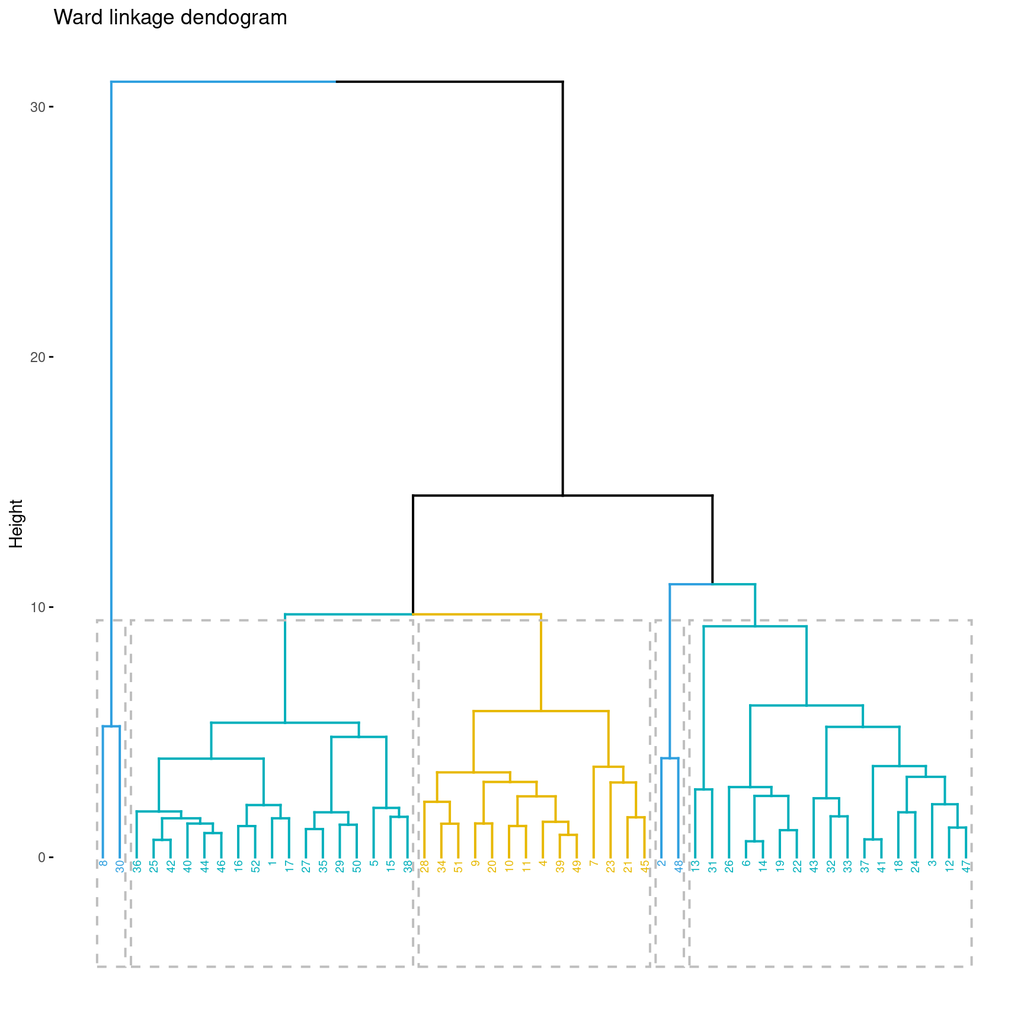

```r
ward_clust <-
  hclust(d, method = "ward.D2")

fviz_dend(ward_clust, k = 5,
          cex = 0.5,
          k_colors =
            c("#2E9FDF", "#00AFBB", "#E7B800"),
          color_labels_by_k = TRUE,
          rect = TRUE) +
  labs(title = "Ward linkage dendogram")
```

The third hierarchical cluster is performed with the Ward linkage method and with 5 clusters, as analyzed in the previous sections. We notice that the clusters are better defined and distributed compared to both the single linkage and the complete linkage. We proceed to analyze with 4 clusters using the same Ward linkage to see if there are improvements.

## Ward linkage with 4 clusters

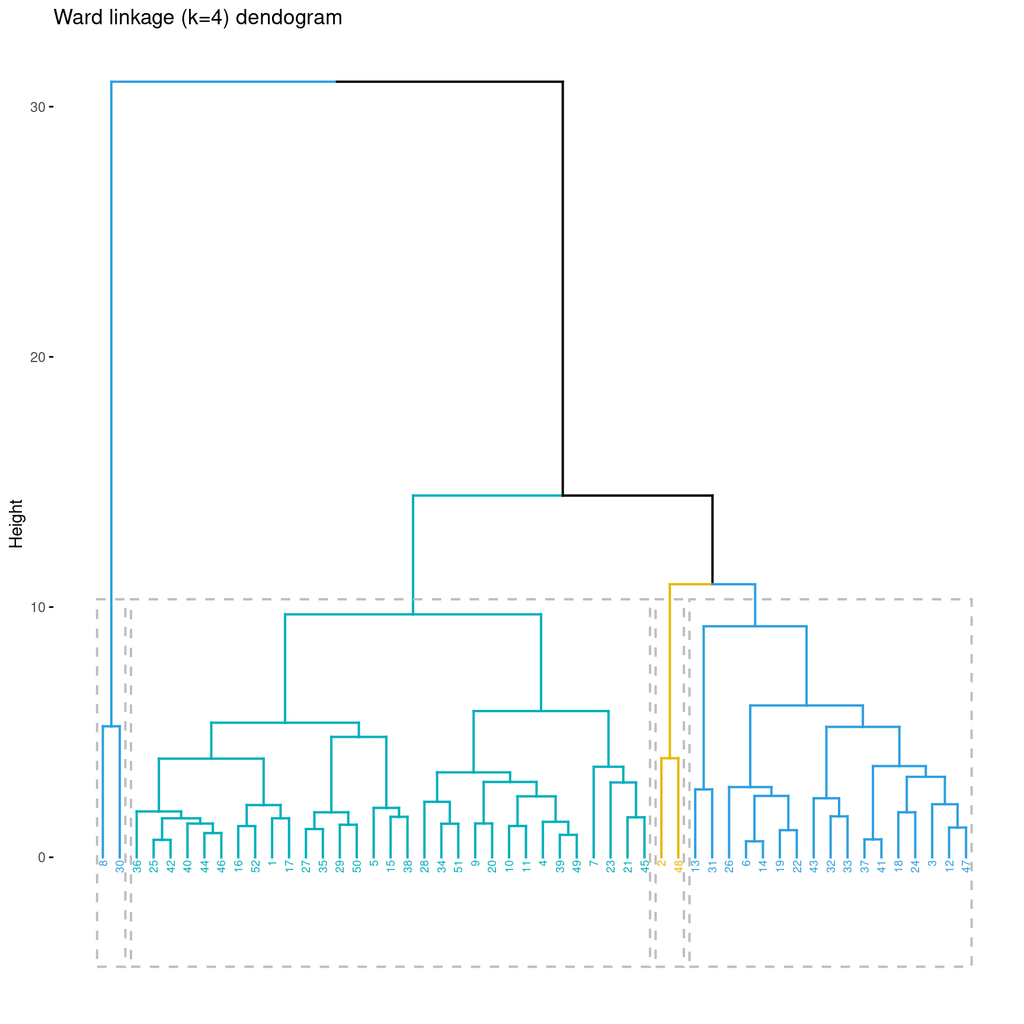

```r
ward_clust <-
  hclust(d, method = "ward.D2")

fviz_dend(ward_clust, k = 4,
          cex = 0.5,
          k_colors =
            c("#2E9FDF", "#00AFBB", "#E7B800"),
          color_labels_by_k = TRUE,
          rect = TRUE) +
  labs(title = "Ward linkage (k=4) dendogram")
```

Finally, we can observe that with 4 clusters, there is no improvement compared to using 5 clusters. Therefore, for this dataset, I recommend using 5 clusters.

# Cluster number optimization

First, we scale our data

```r
#First, we scale our data.
provincias_scale <- provincias %>%
  select(-Prov) %>%
  mutate(across(where(is.numeric),
                rescale))
row.names(provincias_scale) <- provincias %>% pull(Prov)
```

We use scaled data to plot the optimal number of clusters under the Silhouette criterion and Within-Cluster-Sum of Squared Errors criterion using the k-means method.

## Silhouette

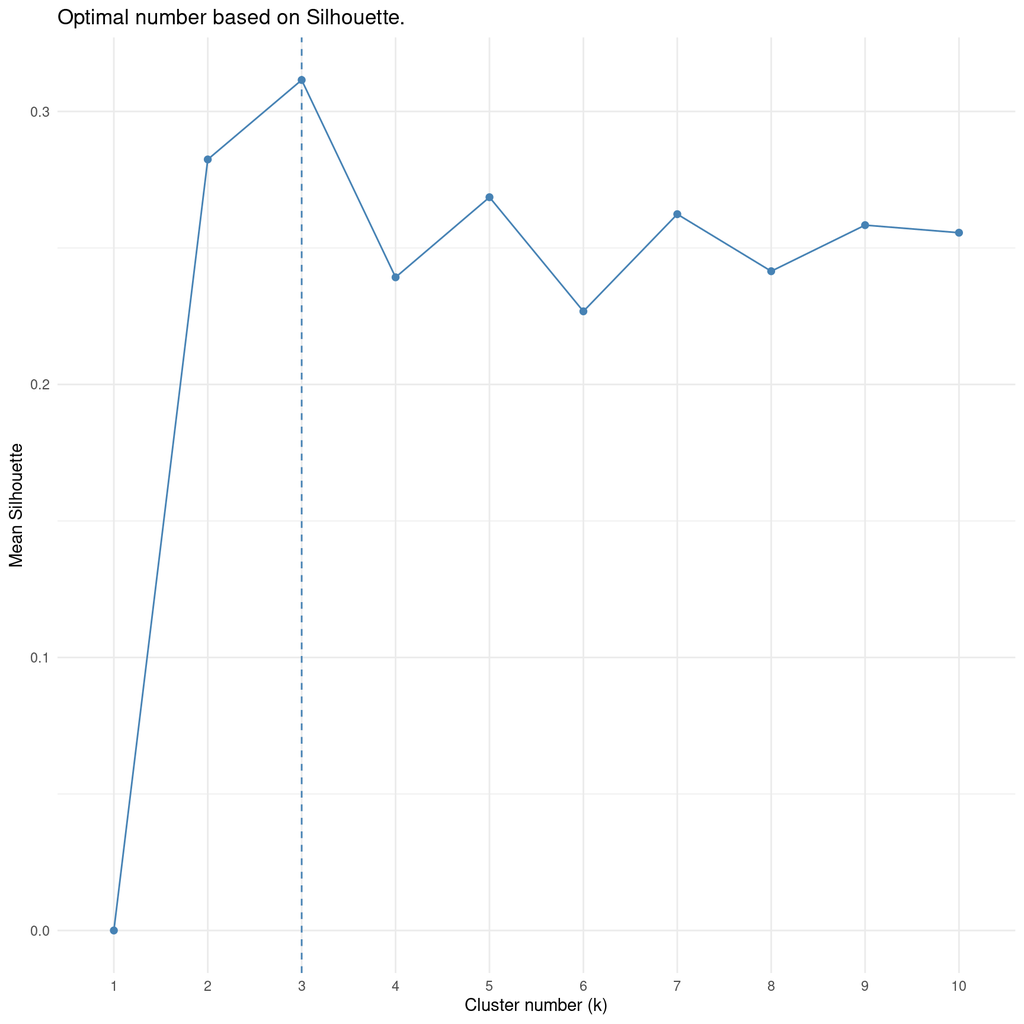

```r
fviz_nbclust(provincias_scale,
             kmeans,
             method = "silhouette") +
  theme_minimal() +
  labs(x = "Cluster number (k)",
       y = "Mean Silhouette",
       title = "Optimal number based on Silhouette.")
```

Under the Silhouette criterion, it indicates an optimal number of clusters equal to 3.

## Within-Cluster Sum of Squared Errors (WSS)

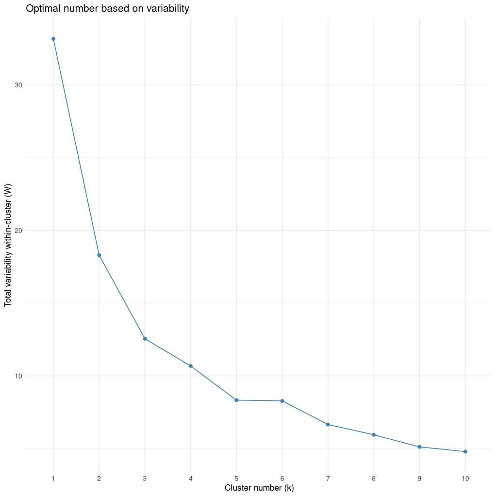

```r
fviz_nbclust(provincias_scale,
             kmeans,
             method = "wss") +
  theme_minimal() +
  labs(x = "Cluster number (k)",
       y = "Total variability within-cluster (W)",
       title = "Optimal number based on variability")
```

And under the WSS criterion, we can observe that the optimal number is 3 clusters.

## Ward linkage with 3 clusters

Finally, using the Ward linkage, we perform clustering with the number of clusters identified earlier as the optimal number for both the Silhouette criterion and the WSS.

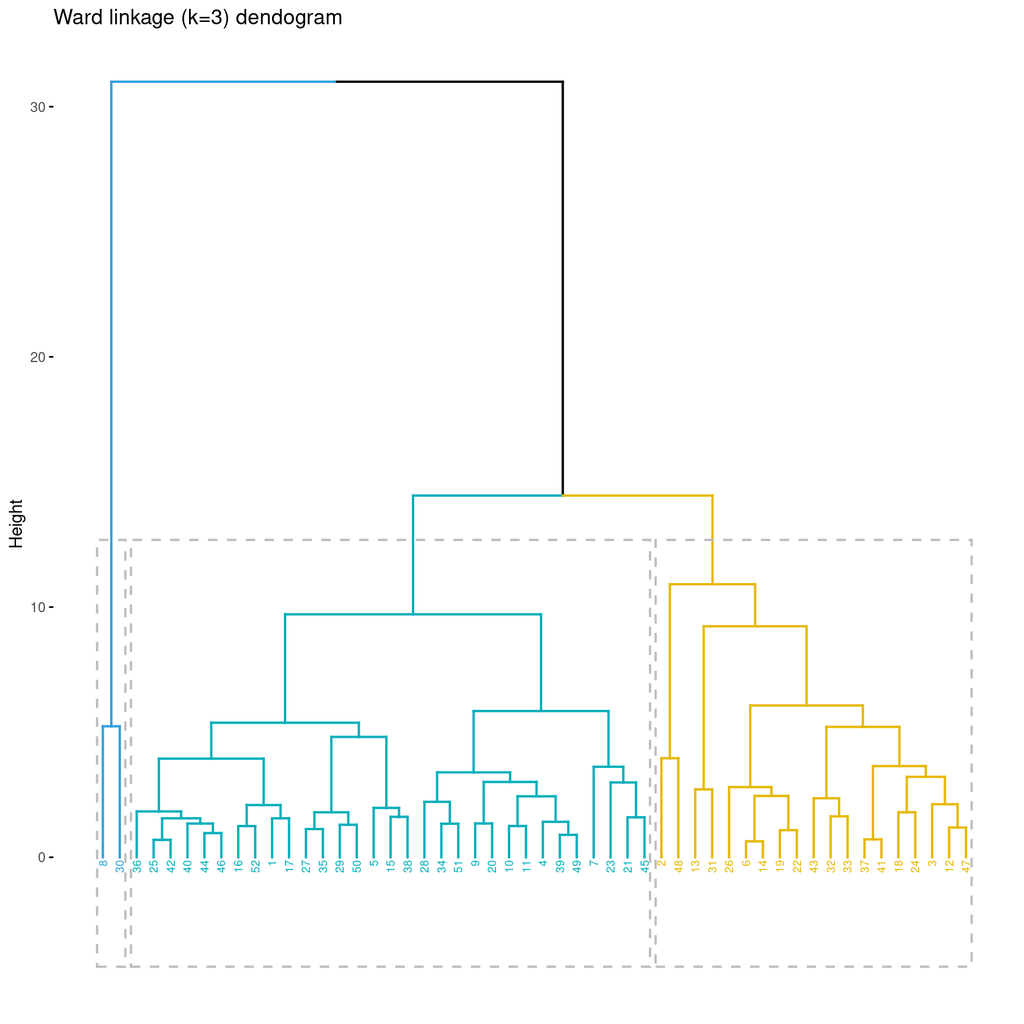

```r
ward_clust <-
  hclust(d, method = "ward.D2")

fviz_dend(ward_clust, k = 3,
          cex = 0.5,
          k_colors =
            c("#2E9FDF", "#00AFBB", "#E7B800"),
          color_labels_by_k = TRUE,
          rect = TRUE) +
  labs(title = "Ward linkage (k=3) dendogram")
```

# K-Means Clustering

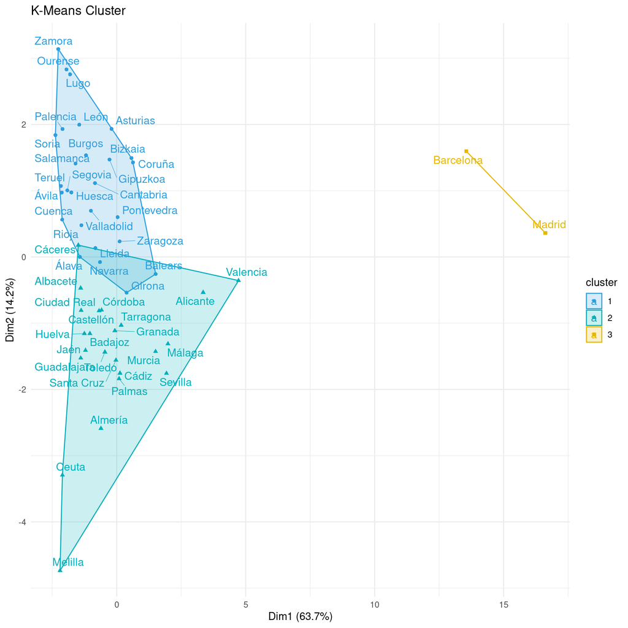

```r
# We use K-Means with the number of cluster calculated before
kclust <- kmeans(provincias_scale,
                 centers = 3,
                 iter.max = 50)

fviz_cluster(list(data =
                    provincias_scale,
                  cluster =
                    kclust$cluster),
             palette =
               c("#2E9FDF", "#00AFBB",
                 "#E7B800"),
             ellipse.type = "convex",
             repel = TRUE,
             show.clust.cent = FALSE) +
  labs(title = "K-Means Cluster") +
  theme_minimal()
```

In the previous clustering plot formed in the plane of the first two principal components, we can observe that clusters 1 and 2 have certain points where the clusters intersect, indicating that the quality of the clustering is not the best. On the other hand, group 3 was well grouped and represented in the plot.

# Silhouette Analysis for K-Means

```
  cluster size ave.sil.width
1       1   27          0.35
2       2   23          0.12
3       3    2          0.67
```

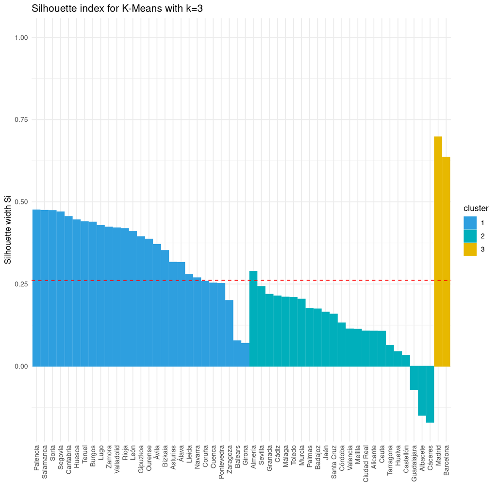

```r
sil <- silhouette(kclust$cluster, d)
row.names(sil) <- row.names(provincias_scale)


fviz_silhouette(sil, label = TRUE) +
  scale_fill_manual(values =
                      c("#2E9FDF", "#00AFBB",
                        "#E7B800")) +
  scale_color_manual(values =
                      c("#2E9FDF", "#00AFBB",
                        "#E7B800")) +
  theme_minimal() +
  labs(title =
         "Silhouette index for K-Means with k=3") +
  theme(axis.text.x =
          element_text(angle = 90,
                       vjust = 0.5,
                       hjust=1))
```

# Conclusions